# Blockchain Bonus: Ethereum and Layer 2

DS 653 Spring 2025  
Built by Tejovan Parker with resources from the [official ethereum developer documentation](https://ethereum.org/en/developers/docs/), Preethi Kasireddy’s blog post [“How does Ethereum work, anyway?”](https://preethikasireddy.medium.com/how-does-ethereum-work-anyway-22d1df506369), and Nicolas Alhaddad’s lecture notes from previous semester.”

# Ethereum: A Quick Overview

Assuming some knoweldge of Bitcoin, or other blockchain cryptocurrency

## A General Computer: slow but secure

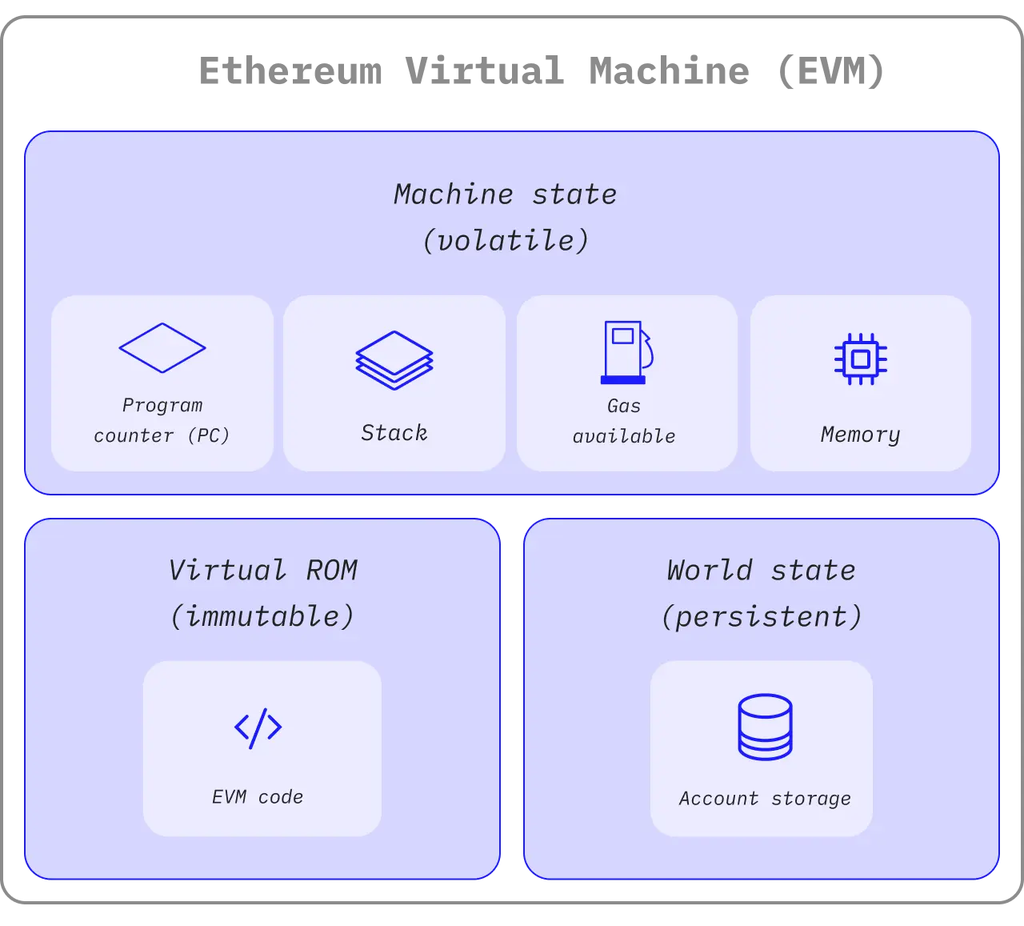

From [Ethereum](https://ethereum.org/en/developers/docs/evm/)

The computer state is updated in “blocks”, by running batches of operations initiated by selected batch of “transactions” broadcast to the Ethereum node network. A new block should be made every 12 seconds, and the computer can process 10-15 transactions per second.

A random “elected” node proposes each new block, and other nodes validate and gossip it to the rest of the network. Every node in the Ethereum network should continually update the state of their local copy of the Ethereum computer.

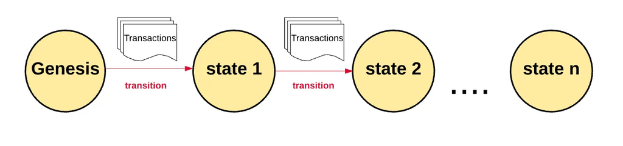

From [Kasireddy](https://preethikasireddy.medium.com/how-does-ethereum-work-anyway-22d1df506369)

Each state is a block

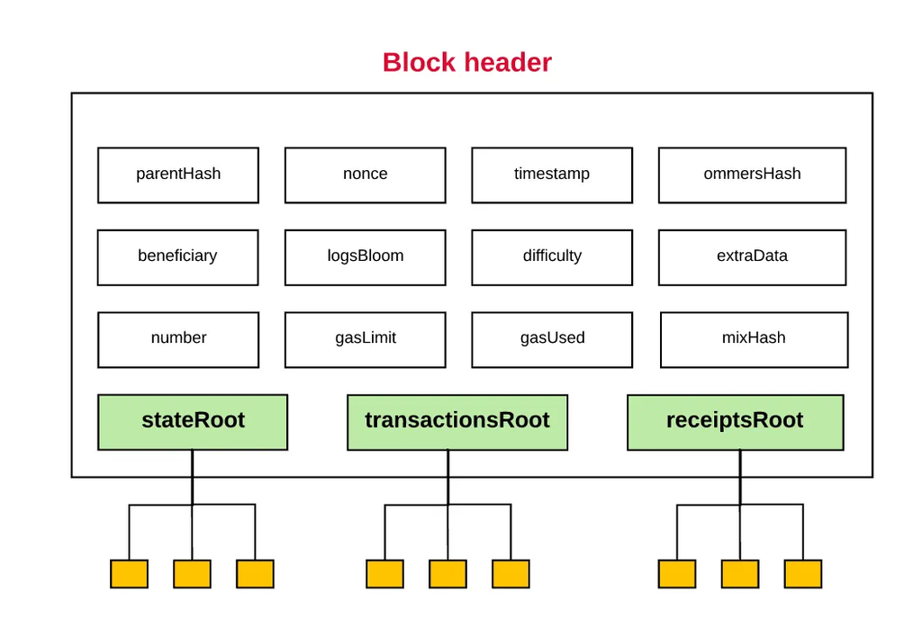

From [Kasireddy](https://preethikasireddy.medium.com/how-does-ethereum-work-anyway-22d1df506369)

## Siloed Computer: Accounts

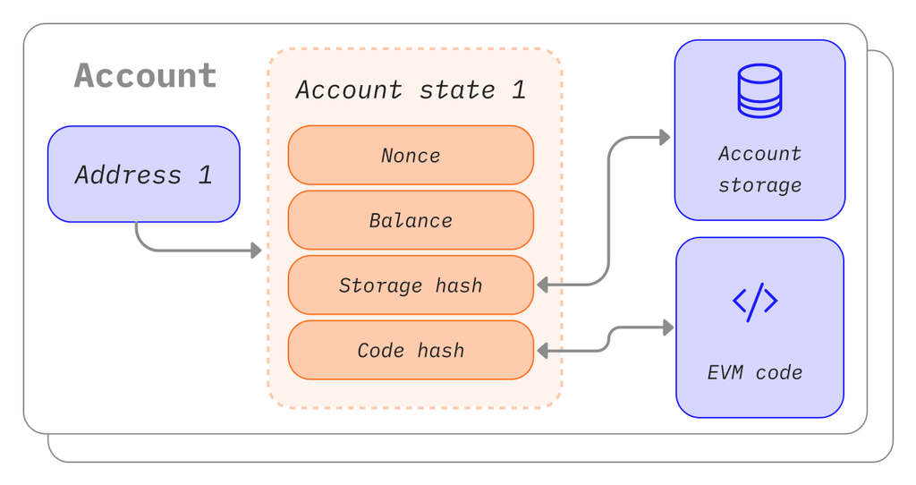

From [Ethereum](https://ethereum.org/en/developers/docs/accounts/)

**Two types of accounts**

- external accounts (public-private keys, no code, stored externally)
- contract accounts (A program or application, with code and storage)

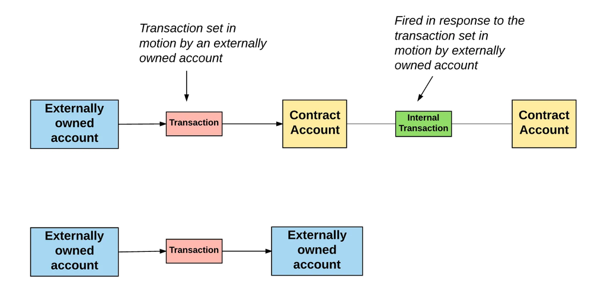

From [Ethereum](https://ethereum.org/en/developers/docs/accounts/)

All accounts can hold Ether. Contracts can send transactions, but only when triggered by an incoming transaction.

**Transactions**

Transactions can do many things, from simply transfering Ether between external accounts, or initiating entire new contract accounts, or commanding contracts.

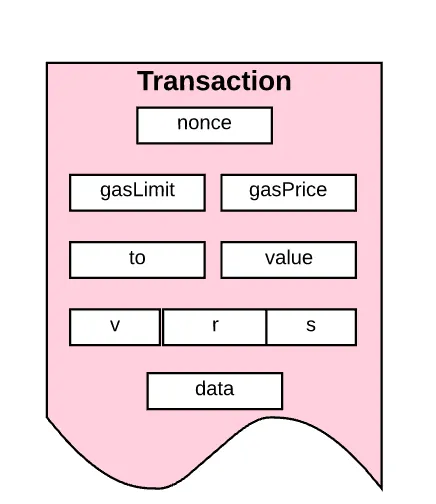

From [Kasireddy](https://preethikasireddy.medium.com/how-does-ethereum-work-anyway-22d1df506369)

## Ether, Gas, Block Rewards

If Ethereum is essentially a computer, and anybody can cause any code they want to be executed on it, then how do we avoid malicious or accidental behavior that would break the computer or consititute a denial-of-service attack? Like:

- computer crashes
- infinite loops
- excessive or exploitive or wasteful computation

Entire system crashes are avoided by having each contract operate in a siloed independent environemnt, or “Ethereum Virtual Machine”. Also, the computer’s state could be repaired simply by a social process where a large set of nodes discuss off-chain and agree to change the computer state.

Excessive computation and denial-of-service is avoided because, essentially, it costs Ether (cryptocurrency) to perform computation and store things on Ethereum.

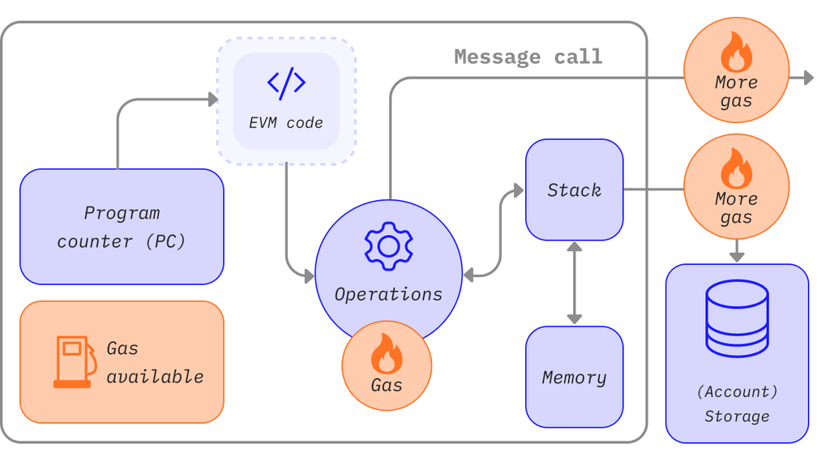

From [Ethereum](https://ethereum.org/content/developers/docs/gas/gas.png)

Ether is the currency of Ethereum. Ether is minted as a reward to proposers and validators of new blocks. Additionally, there are Ether fees for every bit of storage and operation performed on Ethereum.

Transactions specify a base fee (in Ether per operation), which gets burned (destroyed) for every operation that occurs. The tip fee is given to the block proposer (creator). Each transaction and contract gets charged up with “gas” by setting a gas limit, which the transaction initiator must have available. Essentially, gas is Ether that can be spent to cover the fees per operation and storage. If the gas runs out before a transaction or contract is completed, then the gas (Ether) is not returned and all changes from that transaction are reverted. Contracts are only reverted to the state before the most recent transaction which whos commands could not be completed.

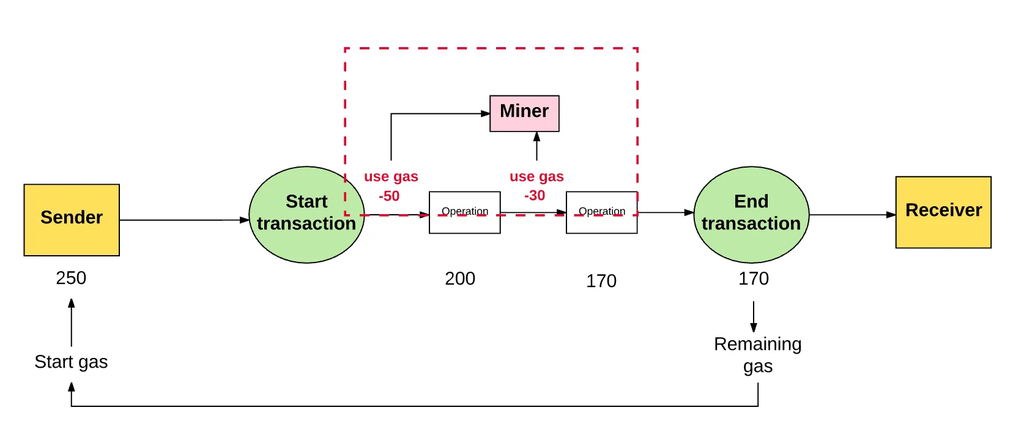

From [Kasireddy](https://preethikasireddy.medium.com/how-does-ethereum-work-anyway-22d1df506369)

## Block Creation

Proof-of-Work is super slow and wastes so much computation. Also, only miners with specialzed hardware can realistically participate. Why don’t we just run a random lottery for every node on the network?

- Because of sybil attacks

How to prevent sybil attacks? Make each lottery ticket cost something:

- Risk or stake (Escrow some money. Lose it if you misbehave. “proof-of-stake”)
  - Regular buying (like escrow, but no chance of getting it back). Incentive and fairness?
- Excercise of work (perform a sha-256 hash, aka “proof-of-work”)
- Other?

#### Poof-of-Stake

Ethereum switched from proof-of-work to proof-of-stake in September 2022. Nodes that wish to earn block rewards must stake 32 Ether (ETH) to become a “validator”. A random validator is chosen for every block to be the proposer of the block. The validator does the work of choosing transactions and exectuing their consequences to the Ethereum state. Then a random commitee of other validators check the new block for validity, signing it to approve. And the new block is gossiped to the network. If validators behave improperly, they can have part of the 32 ETH stake “slashed” (destroyed).

Note on common randomness: later in this course we will learn about how a set of nodes can run a distributed, secure, random lottery.

#### Ether Value and Security

Only Ethereum block creators can generate Ether, and generating blocks takes some work. So Ether has some scarcity, or limited supply. Anyone else who wants to use the Ethereum computer must buy Ether from someone else. People are willing to buy Ether is they think it is valuable to them to be able to do secure computations with global consensus. This gives Ether value.

What sorts of security guarantees does the value of Ether give Ethereum and Proof-of-Stake?

# Layer 2 (relying on blockchain off-chain)

Blockchains give us consensus! We can perform any accounting, beaurocratic, or other computational tasks verifiably, securely, and immutably (un-tamperably) without trusting a central authority!

But, we have sacrificed, like, all efficiency and scalability to get that. Can we get both efficiency and secure distributed consensus?

What if we could do lots of efficient and quick off-chain activity in a way that, if anyone tries to cheat, we could always go back to a slow and expensive ‘recovery’ procedure on-chain to rectify the cheating?

## Some Necesarry Cryptographic Primatives

### Multi-signature Schemes

N out of M private keys needed to create a valid signature.

So, a 4/7 (or 4-of-7) signature scheme would require at least 4 out of 7 secrete keys to be used to create a valid signature.

How the heck does that work? Ask Prof. Varia.

### Time Locks

Like a signature, except instead of detecting which secret-public key pair was used, and instead detects whether the signature occured more than a certain amount of time ago.

How the heck can it keep time if it’s not ‘alive’, continually counting down over time? Ask Prof. Varia.

### Hash Locks

Remember, the address Bitcoins are sent to are hashes of a public key. Because of the properties of hash functions, no one can guess the public key from the address. Knowledge of the public key is also necesarry to use the Bitcions.

In this way, you can think of the Bitcoins as being “hash-locked”.

## Bitcoin Lightning Network

Go to other slides